# MAT02014 - Planejamento de Experimentos II Efeitos aninhados

Rodrigo Citton P. dos Reis `rodrigocpdosreis@gmail.com` Universidade Federal do Rio Grande do Sul Instituto de Matemática e Estatística Departamento de Estatística

Porto Alegre, 2018

## Onde estamos?

- Até aqui:
  - Efeitos fixos
  - Efeitos aleatórios
  - Ambos no contexto de delineamentos **fatoriais cruzados**
- Agora:
  - Estrutura de **fatores aninhados**
  - **Modelos mistos:** uma combinação de efeitos fixos e aleatórios.

# Delineamentos fatoriais com efeitos aninhados

## Relembrando: fatores cruzados

- Com os **fatores cruzados** $A$ e $B$, **vemos** (por definição) **todas as combinações possíveis** de níveis de fatores, ou seja, podemos configurar uma tabela de dados da seguinte forma

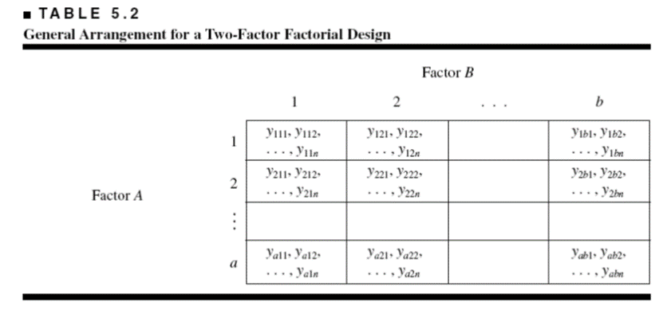

## Relembrando: fatores cruzados

- Isto significa: vemos **cada nível** do fator $A$ em **todos os níveis** do fator $B$ (e vice-versa).
- O nível 1 do fator $A$ tem o mesmo significado em **todos os níveis** do fator $B$.

## Exemplo: desempenho de alunos

- Queremos analisar o desempenho de alunos.
- Dados de diferentes **turmas** de diferentes **escolas** (a nível de **aluno**).
- Qual o (grau) de variabilidade
  - entre diferentes escolas?
  - entre turmas **dentro** da mesma escola?
  - entre alunos **dentro** da mesma turma?
- Isso parece um **novo delineamento**, pois as turmas claramente **não** são cruzadas com escolas, similarmente para alunos.
- Isso nos leva a uma nova definição …

## Estrutura de fatores aninhados

- Nós chamamos fator $B$ **aninhado** no fator $A$ se tivermos níveis diferentes de $B$ dentro de cada nível de $A$.

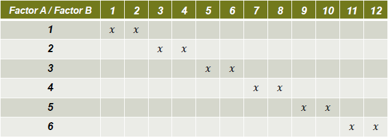

- Por exemplo, pense em
  - $A$: escola
  - $B$: turma
- Também escrevemos $B(A)$.
- Os dados não são necessariamente apresentados neste formato.

## Fatores aninhados: exemplo

- Dados apresentados

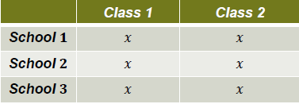

- Estrutura dos dados subjacente

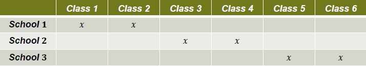

- Portanto, a turma é aninhada na escola, pois a classe 1 na escola 1 não tem nada a ver com classe 1 na escola 2.

## Fatores aninhados

- Só porque as turmas são rotuladas 1 e 2 não significa que é um delineamento fatorial cruzado.
- Portanto, pergunte-se sempre se o nível 1 do fator realmente corresponde ao mesmo objeto em todos os níveis do outro fator.
- Geralmente, usamos parênteses no índice para indicar aninhamento, ou seja, o modelo é escrito como

$$Y_{ijk} = \mu + \alpha_i + \beta_{j(i)} + \epsilon_{k(ij)}$$

- $\alpha_{i}$: efeito de escola
- $\beta_{j(i)}$: efeito de turma dentro de escola
- $\epsilon_{k(ij)}$: erro aleatório; também escritos na “notação aninhada”

## Por que aninhar?

- Tipicamente usamos uma estrutura aninhada devido a restrições práticas/logísticas.
- Por exemplo:
  - Pacientes são aninhados em hospitais, pois não iremos enviar pacientes para todas as clínicas.
  - As amostras são aninhadas em lotes (controle de qualidade).

## Exemplo: delineamento completamente aninhado

- Chamamos um delineamento completamente aninhado se cada fator estiver aninhado em seu predecessor.

### Exemplo de genômica:

- Considere três subespécies.
- Escolha aleatoriamente cinco machos de cada subespécie (= 15 machos).
- Cada macho é acasalado com quatro fêmeas diferentes da mesma subespécie (= 60 fêmeas).
- Observe 3 filhotes por acasalamento (= 180 filhotes).
- Faça duas medições por filhote (= 360 medições)

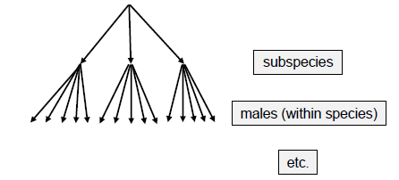

## Exemplo: delineamento completamente aninhado

- Usamos o modelo

$$Y_{ijklm} = \mu + \alpha_i + \beta_{j(i)} + \gamma_{k(ij)} + \delta_{l(ijk)} + \epsilon_{m(ijkl)}$$

- **Exercício:** liste os efeitos do modelo para o exemplo discutido.
- Para calcular a correspondente soma de quadrados, usamos a decomposição

$$\begin{eqnarray*}
(y_{ijklm} - \bar{y}_{.....}) &=& (\bar{y}_{i....} - \bar{y}_{.....}) + (\bar{y}_{ij...} - \bar{y}_{i....})\\
&&\quad + (\bar{y}_{ijk..} - \bar{y}_{ij...}) + (\bar{y}_{ijkl.} - \bar{y}_{ijk..}) \\
&&\quad + (\bar{y}_{ijklm} -\bar{y}_{ijkl.}).
\end{eqnarray*}$$

elevamos ao quadrado e somamos sobre todos os índices.

## Tabela de ANOVA para delineamentos completamente aninhados

- Temos a seguinte decomposição

$$SS_T = SS_A + SS_{B(A)} + SS_{C(AB)} ++ SS_{D(ABC)} + SS_E$$

- Assumindo que temos apenas **efeitos aleatórios** e um delineamento **balanceado**, temos a seguinte tabela de ANOVA

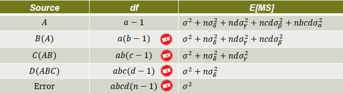

- Com esta informação podemos construir **testes** e **estimadores** para diferentes componentes de variância.

## Tabela de ANOVA para delineamentos completamente aninhados

- Testes $F$ são construídos considerando a razão dos quadrados médios dos erros “vizinhos”, já que eles diferem apenas pelo componente de variação de interesse.
- Isso significa que sempre usamos o quadrado médio do do sucessor na hierárquia como denominador.
- Por exemplo, $F = \frac{MS_A}{MS_{B(A)}}$ para testar $H_0: \sigma^2_{\alpha} = 0$ *vs.* $H_1: \sigma^2_{\alpha} > 0$.

## Exemplo: força da pasta

- Conjunto de dados do pacote `lme4`.
- Produto de pasta química contido em barris.
- 10 **entregas** (**lotes**) foram selecionadas **aleatoriamente**.
- De cada entrega, 3 **barris** foram selecionados **aleatoriamente**.
- Por barril: faça duas **medições**.

## Exemplo (R)

```r
library(lme4)
data(Pastes)
head(Pastes)
```

```
##   strength batch cask sample
## 1     62.8     A    a    A:a
## 2     62.6     A    a    A:a
## 3     60.1     A    b    A:b
## 4     62.3     A    b    A:b
## 5     62.7     A    c    A:c
## 6     63.1     A    c    A:c
```

```r
tail(Pastes)
```

```
##    strength batch cask sample
## 55     58.3     J    a    J:a
## 56     59.3     J    a    J:a
## 57     59.2     J    b    J:b
## 58     59.2     J    b    J:b
## 59     58.9     J    c    J:c
## 60     56.6     J    c    J:c
```

## Exemplo (R)

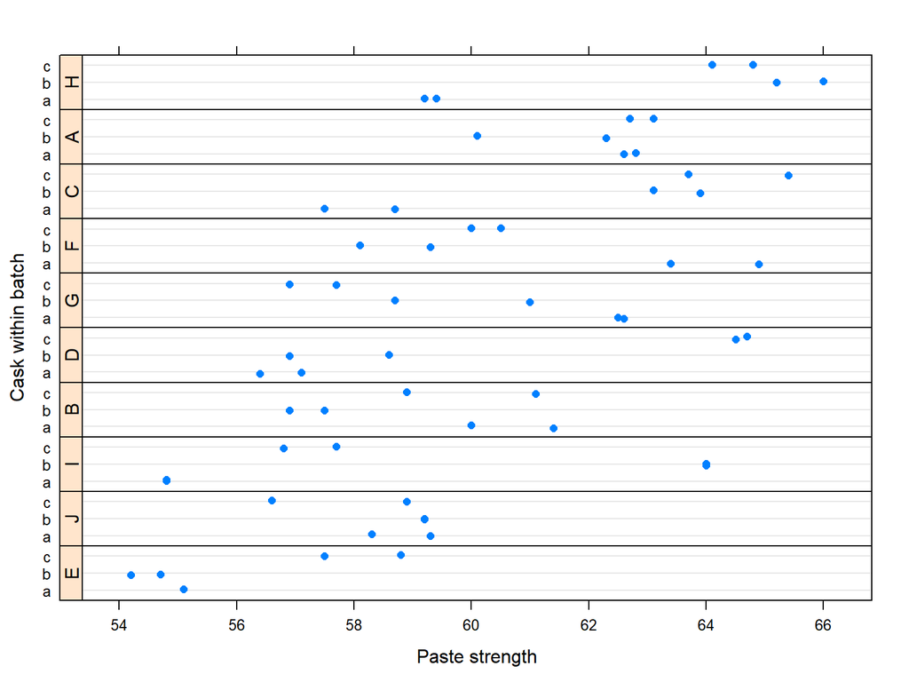

## Exemplo (R)

```r
fit <- aov(strength ~ batch + batch:cask, data = Pastes)
#fit <- aov(strength ~ batch/cask, data = Pastes) ## equivalent formulation
#fit <- aov(strength ~ batch + cask %in% batch, data = Pastes)
summary(fit)
```

```
##             Df Sum Sq Mean Sq F value   Pr(>F)
## batch        9  247.4  27.489   40.55 2.28e-14 ***
## batch:cask  20  350.9  17.545   25.88 9.79e-14 ***
## Residuals   30   20.3   0.678
## ---
## Signif. codes:  0 '***' 0.001 '**' 0.01 '*' 0.05 '.' 0.1 ' ' 1
```

## Exemplo (R)

- Da saída podemos manualmente calcular os diferentes componentes de variância resolvendo as equações que correspondem às esperanças dos quadrados médios.
- **Exercício:** (1) qual é este método de estimação? (2) Estime os componentes de variância.

```
##             Df Sum Sq Mean Sq F value   Pr(>F)
## batch        9  247.4  27.489   40.55 2.28e-14 ***
## batch:cask  20  350.9  17.545   25.88 9.79e-14 ***
## Residuals   30   20.3   0.678
## ---
## Signif. codes:  0 '***' 0.001 '**' 0.01 '*' 0.05 '.' 0.1 ' ' 1
```

## Exemplo (R)

### Método dos momentos

```r
sigma2 <- .678
sigma2bc <- (17.545 - sigma2) / 2
sigma2b <- (27.489 - sigma2 - 2 * sigma2bc ) / (2*3)
cat("Method of Moments Variance Component Estimates","\n",
    "Var(error)=",sigma2,"\n","Var(C(B))=",sigma2bc,"\n",
    "Var(B)=",sigma2b,"\n")
```

```
## Method of Moments Variance Component Estimates
##  Var(error)= 0.678
##  Var(C(B))= 8.4335
##  Var(B)= 1.657333
```

## Exemplo (R)

- Similarmente, testes têm que ser computados manualmente.
- Por exemplo, para o componente de variância de lote:

```r
pf(27.489 / 17.545, 9, 20, lower.tail = FALSE)
```

```
## [1] 0.1925487
```

- Assim, não podemos rejeitar $H_0: \sigma^2_A = 0$.

## Exemplo (R)

```r
## lmer approaches (all equivalent) ####
fm1 <- lmer(strength ~ (1 | batch/cask), data = Pastes)
summary(fm1)
```

```
## Linear mixed model fit by REML ['lmerMod']
## Formula: strength ~ (1 | batch/cask)
##    Data: Pastes
##
## REML criterion at convergence: 247
##
## Scaled residuals:
##     Min      1Q  Median      3Q     Max
## -1.4798 -0.5156  0.0095  0.4720  1.3897
##
## Random effects:
##  Groups     Name        Variance Std.Dev.
##  cask:batch (Intercept) 8.434    2.9041
##  batch      (Intercept) 1.657    1.2874
##  Residual               0.678    0.8234
## Number of obs: 60, groups:  cask:batch, 30; batch, 10
##
## Fixed effects:
##             Estimate Std. Error t value
## (Intercept)  60.0533     0.6769   88.72
```

## Exemplo (R)

```r
confint(fm1, oldNames = FALSE)
```

```
##                                2.5 %    97.5 %
## sd_(Intercept)|cask:batch  2.1579337  4.053589
## sd_(Intercept)|batch       0.0000000  2.946591
## sigma                      0.6520234  1.085448
## (Intercept)               58.6636504 61.443016
```

## Exemplo (R)

```r
fm2 <- lmer(strength ~ (1 | batch) + (1 | cask:batch), data = Pastes)
library(lmerTest)
rand(fm2)
```

```
## Analysis of Random effects Table:
##            Chi.sq Chi.DF p.value
## batch       0.658      1     0.4
## cask:batch 54.605      1   1e-13 ***
## ---
## Signif. codes:  0 '***' 0.001 '**' 0.01 '*' 0.05 '.' 0.1 ' ' 1
```

## Exemplo

- **Pergunta:** o que podemos concluir?

## Exemplo (R)

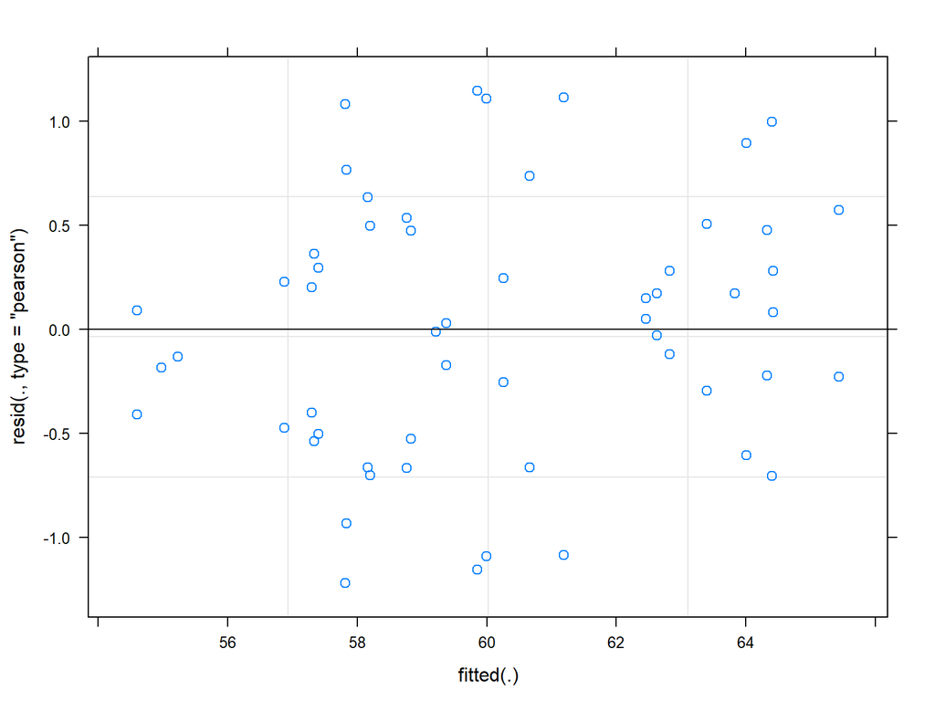

```r
## residual analysis ####
plot(fm1) ## Tukey-Anscombe plot
```

## Exemplo (R)

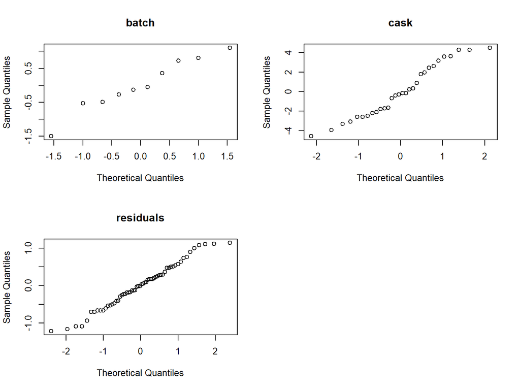

```r
par(mfrow = c(2,2))
qqnorm(ranef(fm1)$batch[,1], main = "batch")
qqnorm(ranef(fm1)$'cask:batch'[,1], main = "cask")
qqnorm(resid(fm1), main = "residuals")
```

## Próxima aula

- Lista de exercícios 2 **(não haverá aula presencial)**